# Classifying the Quality of Weight Lifting Exercises

Mathias Mathieu

04/06/2017

## Introduction

In this report we will discuss the results of building a classifier for weight lifting exercises. The data set used was constructed by letting six participants perform weight lifting exercises in 5 different ways, the correct way and with 4 common mistakes. The movements of the participants and weights were monitored using wearable sensors.  
The goal was to use this movement data, and build a classifier that can recognize in which way, at each point in time, the exercise was done. We used the random forest algorithm to build our classifier, using most of the default settings, but with 10-fold cross validation in stead of bootstrapping the samples. This was done to decrease the time needed to build to model.  
The constructed model was found to be very accurate, with a perfect accuracy for the training data, and over 99% accuracy on the test set. On the 20 test cases for the quiz, all cases were classified correctly.

## Exploratory Analysis

First we load the necessary libraries.

```r
library(caret)
library(parallel)
library(doParallel)
library(foreach)
```

We set the seed for the random generator to ensure reproducibility. We then load the data sets, and create a training and test set.

```r
#set seed for reproducibility
set.seed(54836)

#load data sets
pmltraining <- read.csv("pml-training.csv",na.strings=c("NA",""))
pmltesting <- read.csv("pml-testing.csv",na.strings=c("NA",""))

#split data into train and test sets
intrain <- createDataPartition(y=pmltraining$classe,p=.7,list=FALSE)
train <- pmltraining[intrain,]
test <- pmltraining[-intrain,]

#used in the appendix
train.old <- train
```

For a look at the structure of the data, see the appendix.  
A lot of values in the data are NA values. We now calculate the fraction of NA’s in each column, and see that some columns have a very large percentage of NA’s. We pick a column with lots of NA’s and check if, when the value of this column is not NA, this has an obvious effect on the class.  
We see the classes are more or less evenly distributed, so there is no obvious influence. We can safely omit the columns with a lot of NA values. We also omit the first seven columns of the data sets, since these contain no information about the movement, but data like the subject name, timestamps, etc.  
Finally we check if any column has a near zero variance. This is not the case, so no extra columns are omitted

```r
#fraction of values which are NA, per column
nas <- apply(apply(train,2,is.na),2,sum)/length(train$X)
unique(nas)
```

```
## [1] 0.0000000 0.9791075
```

```r
#check if non-na's have an obvious influence on classification (w kurtosis_roll_belt as example)
table(train[!is.na(train$kurtosis_roll_belt),]$classe)
```

```
##
##  A  B  C  D  E
## 82 55 47 51 52
```

```r
#no -> remove variables
train <- train[,nas==0]
train <- train[,-seq(1,7)]

test <- test[,nas==0]
test <- test[,-seq(1,7)]

#check if any variables have a near zero variance
any(nearZeroVar(train,saveMetrics = TRUE)$nzv)
```

```
## [1] FALSE
```

## Building the Model

We now build the random forest model. We use the parallelisation capabilities of R to decrease the build time. We use 10-fold cross validation for resampling the data in stead of bootstrapping, also to decrease the time needed. Since the final model proved to be very accurate, this seems to have had little effect on the final accuracy.

```r
#create and register cluster
cluster <- makeCluster(detectCores()-1)
registerDoParallel(cluster)

#train random forest model
fitcontrol <- trainControl(method="cv",number=10,allowParallel = TRUE)
modfit <- train(classe~.,data=train,method="rf", trControl=fitcontrol)

#stop cluster, return to sequential execution
stopCluster(cluster)
registerDoSEQ()
```

## Testing the Model

Now we test the model we obtained in the last step, by using the *confusionMatrix* method from *caret*. We see the model has perfect accuracy on the training data, and 99.2% accuracy on the test data, which gives a more realistic number for the accuracy, because overfitting plays a smaller role here.

```r
#confusion matrix and statistics for train data
confusionMatrix(predict(modfit,train),train$classe)
```

```
## Confusion Matrix and Statistics
##
##           Reference
## Prediction    A    B    C    D    E
##          A 3906    0    0    0    0
##          B    0 2658    0    0    0
##          C    0    0 2396    0    0
##          D    0    0    0 2252    0
##          E    0    0    0    0 2525
##
## Overall Statistics
##
##                Accuracy : 1
##                  95% CI : (0.9997, 1)
##     No Information Rate : 0.2843
##     P-Value [Acc > NIR] : < 2.2e-16
##
##                   Kappa : 1
##  Mcnemar's Test P-Value : NA
##
## Statistics by Class:
##
##                      Class: A Class: B Class: C Class: D Class: E
## Sensitivity            1.0000   1.0000   1.0000   1.0000   1.0000
## Specificity            1.0000   1.0000   1.0000   1.0000   1.0000
## Pos Pred Value         1.0000   1.0000   1.0000   1.0000   1.0000
## Neg Pred Value         1.0000   1.0000   1.0000   1.0000   1.0000
## Prevalence             0.2843   0.1935   0.1744   0.1639   0.1838
## Detection Rate         0.2843   0.1935   0.1744   0.1639   0.1838
## Detection Prevalence   0.2843   0.1935   0.1744   0.1639   0.1838
## Balanced Accuracy      1.0000   1.0000   1.0000   1.0000   1.0000
```

```r
#confusion matrix and statistics for test data
confusionMatrix(predict(modfit,test),test$classe)
```

```
## Confusion Matrix and Statistics
##
##           Reference
## Prediction    A    B    C    D    E
##          A 1669    5    0    0    0
##          B    5 1131    9    0    1
##          C    0    3 1016   14    2
##          D    0    0    1  946    2
##          E    0    0    0    4 1077
##
## Overall Statistics
##
##                Accuracy : 0.9922
##                  95% CI : (0.9896, 0.9943)
##     No Information Rate : 0.2845
##     P-Value [Acc > NIR] : < 2.2e-16
##
##                   Kappa : 0.9901
##  Mcnemar's Test P-Value : NA
##
## Statistics by Class:
##
##                      Class: A Class: B Class: C Class: D Class: E
## Sensitivity            0.9970   0.9930   0.9903   0.9813   0.9954
## Specificity            0.9988   0.9968   0.9961   0.9994   0.9992
## Pos Pred Value         0.9970   0.9869   0.9816   0.9968   0.9963
## Neg Pred Value         0.9988   0.9983   0.9979   0.9964   0.9990
## Prevalence             0.2845   0.1935   0.1743   0.1638   0.1839
## Detection Rate         0.2836   0.1922   0.1726   0.1607   0.1830
## Detection Prevalence   0.2845   0.1947   0.1759   0.1613   0.1837
## Balanced Accuracy      0.9979   0.9949   0.9932   0.9904   0.9973
```

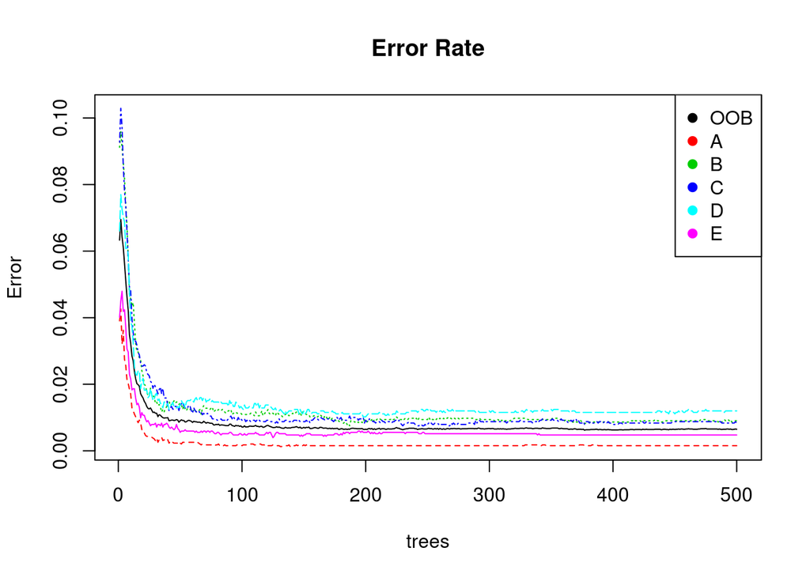

```r
#diagnostic plots
plot(modfit$finalModel,main="Error Rate")
legend("topright",legend=colnames(modfit$finalModel$err.rate),col=1:6,pch=19)
```

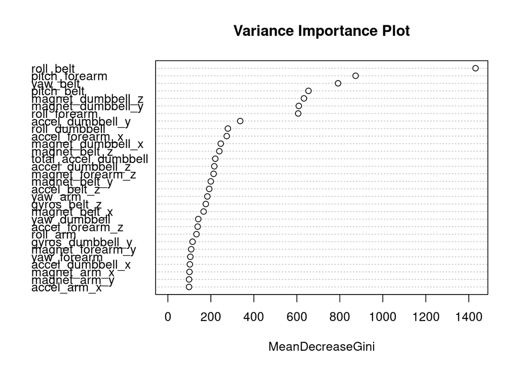

```r
varImpPlot(modfit$finalModel,main="Variance Importance Plot")
```

Finally the model is applied to quiz test cases. The results are not shown, because of Coursera policies, but they were all classified correctly.

```r
#quiz data
pmltesting <- pmltesting[,nas==0]
pmltesting <- pmltesting[,-seq(1:7)]

predict(modfit,pmltesting)
```

## Conclusion

The random forest model is very accurate on this data set, the only drawback being the rather large time needed to build the model. The out of sample accuracy attained was around 99.2%. With this technique, it is feasible to predict in which manner the weight lifting exercises, either correctly or with which type of error, are done.

## Appendix

The structure and a summary of the training data set:

```r
head(train.old,n=1)
```

```
##   X user_name raw_timestamp_part_1 raw_timestamp_part_2   cvtd_timestamp
## 1 1  carlitos           1323084231               788290 05/12/2011 11:23
##   new_window num_window roll_belt pitch_belt yaw_belt total_accel_belt
## 1         no         11      1.41       8.07    -94.4                3
##   kurtosis_roll_belt kurtosis_picth_belt kurtosis_yaw_belt
## 1               <NA>                <NA>              <NA>
##   skewness_roll_belt skewness_roll_belt.1 skewness_yaw_belt max_roll_belt
## 1               <NA>                 <NA>              <NA>            NA
##   max_picth_belt max_yaw_belt min_roll_belt min_pitch_belt min_yaw_belt
## 1             NA         <NA>            NA             NA         <NA>
##   amplitude_roll_belt amplitude_pitch_belt amplitude_yaw_belt
## 1                  NA                   NA               <NA>
##   var_total_accel_belt avg_roll_belt stddev_roll_belt var_roll_belt
## 1                   NA            NA               NA            NA
##   avg_pitch_belt stddev_pitch_belt var_pitch_belt avg_yaw_belt
## 1             NA                NA             NA           NA
##   stddev_yaw_belt var_yaw_belt gyros_belt_x gyros_belt_y gyros_belt_z
## 1              NA           NA            0            0        -0.02
##   accel_belt_x accel_belt_y accel_belt_z magnet_belt_x magnet_belt_y
## 1          -21            4           22            -3           599
##   magnet_belt_z roll_arm pitch_arm yaw_arm total_accel_arm var_accel_arm
## 1          -313     -128      22.5    -161              34            NA
##   avg_roll_arm stddev_roll_arm var_roll_arm avg_pitch_arm stddev_pitch_arm
## 1           NA              NA           NA            NA               NA
##   var_pitch_arm avg_yaw_arm stddev_yaw_arm var_yaw_arm gyros_arm_x
## 1            NA          NA             NA          NA           0
##   gyros_arm_y gyros_arm_z accel_arm_x accel_arm_y accel_arm_z magnet_arm_x
## 1           0       -0.02        -288         109        -123         -368
##   magnet_arm_y magnet_arm_z kurtosis_roll_arm kurtosis_picth_arm
## 1          337          516              <NA>               <NA>
##   kurtosis_yaw_arm skewness_roll_arm skewness_pitch_arm skewness_yaw_arm
## 1             <NA>              <NA>               <NA>             <NA>
##   max_roll_arm max_picth_arm max_yaw_arm min_roll_arm min_pitch_arm
## 1           NA            NA          NA           NA            NA
##   min_yaw_arm amplitude_roll_arm amplitude_pitch_arm amplitude_yaw_arm
## 1          NA                 NA                  NA                NA
##   roll_dumbbell pitch_dumbbell yaw_dumbbell kurtosis_roll_dumbbell
## 1      13.05217        -70.494    -84.87394                   <NA>
##   kurtosis_picth_dumbbell kurtosis_yaw_dumbbell skewness_roll_dumbbell
## 1                    <NA>                  <NA>                   <NA>
```

[output cut: 25 more lines]

```
## 1                NA            <NA>               NA                NA
##   min_yaw_forearm amplitude_roll_forearm amplitude_pitch_forearm
## 1            <NA>                     NA                      NA
##   amplitude_yaw_forearm total_accel_forearm var_accel_forearm
## 1                  <NA>                  36                NA
##   avg_roll_forearm stddev_roll_forearm var_roll_forearm avg_pitch_forearm
## 1               NA                  NA               NA                NA
##   stddev_pitch_forearm var_pitch_forearm avg_yaw_forearm
## 1                   NA                NA              NA
##   stddev_yaw_forearm var_yaw_forearm gyros_forearm_x gyros_forearm_y
## 1                 NA              NA            0.03               0
##   gyros_forearm_z accel_forearm_x accel_forearm_y accel_forearm_z
## 1           -0.02             192             203            -215
##   magnet_forearm_x magnet_forearm_y magnet_forearm_z classe
## 1              -17              654              476      A
```

```r
summary(train.old)
```

```
##        X            user_name    raw_timestamp_part_1 raw_timestamp_part_2
##  Min.   :    1   adelmo  :2779   Min.   :1.322e+09    Min.   :   294
##  1st Qu.: 4889   carlitos:2124   1st Qu.:1.323e+09    1st Qu.:252301
##  Median : 9809   charles :2496   Median :1.323e+09    Median :496438
##  Mean   : 9818   eurico  :2124   Mean   :1.323e+09    Mean   :500183
##  3rd Qu.:14726   jeremy  :2390   3rd Qu.:1.323e+09    3rd Qu.:748324
##  Max.   :19622   pedro   :1824   Max.   :1.323e+09    Max.   :998801
##
##           cvtd_timestamp new_window    num_window    roll_belt
##  28/11/2011 14:14:1027   no :13450   Min.   :  1   Min.   :-28.90
##  05/12/2011 11:24:1019   yes:  287   1st Qu.:221   1st Qu.:  1.10
##  02/12/2011 13:34: 997               Median :427   Median :115.00
##  30/11/2011 17:11: 996               Mean   :432   Mean   : 65.02
##  02/12/2011 14:57: 977               3rd Qu.:647   3rd Qu.:123.00
##  05/12/2011 11:25: 977               Max.   :864   Max.   :162.00
##  (Other)         :7744
##    pitch_belt          yaw_belt       total_accel_belt kurtosis_roll_belt
##  Min.   :-55.8000   Min.   :-180.00   Min.   : 0.00    #DIV/0!  :    6
##  1st Qu.:  1.6600   1st Qu.: -88.20   1st Qu.: 3.00    -1.908453:    2
##  Median :  5.2700   Median : -11.60   Median :17.00    -0.021024:    1
##  Mean   :  0.1457   Mean   : -10.13   Mean   :11.38    -0.025513:    1
##  3rd Qu.: 15.2000   3rd Qu.:  14.50   3rd Qu.:18.00    -0.033935:    1
##  Max.   : 60.3000   Max.   : 179.00   Max.   :28.00    (Other)  :  276
##                                                        NA's     :13450
##  kurtosis_picth_belt kurtosis_yaw_belt skewness_roll_belt
##  #DIV/0!  :   26     #DIV/0!:  287     #DIV/0!  :    5
##  47.000000:    4     NA's   :13450     0.000000 :    2
##  -0.684748:    3                       0.422463 :    2
##  -1.750749:    3                       -0.003095:    1
##  -1.851307:    3                       -0.010002:    1
##  (Other)  :  248                       (Other)  :  276
##  NA's     :13450                       NA's     :13450
##  skewness_roll_belt.1 skewness_yaw_belt max_roll_belt     max_picth_belt
##  #DIV/0!  :   26      #DIV/0!:  287     Min.   :-94.300   Min.   : 3.00
##  0.000000 :    3      NA's   :13450     1st Qu.:-88.000   1st Qu.: 5.00
##  6.855655 :    3                        Median : -5.600   Median :18.00
##  -0.189082:    2                        Mean   : -8.387   Mean   :12.67
##  -0.475418:    2                        3rd Qu.:  4.850   3rd Qu.:19.00
##  (Other)  :  251                        Max.   :180.000   Max.   :30.00
##  NA's     :13450                        NA's   :13450     NA's   :13450
```

[output cut: 313 more lines]

```
##  Min.   :-632.0   Min.   :-446.00   Min.   :-1280.0   Min.   :-896.0
##  1st Qu.:  57.0   1st Qu.:-181.00   1st Qu.: -615.0   1st Qu.:   4.0
##  Median : 201.0   Median : -38.00   Median : -376.0   Median : 593.0
##  Mean   : 163.7   Mean   : -54.83   Mean   : -311.4   Mean   : 380.4
##  3rd Qu.: 312.0   3rd Qu.:  26.00   3rd Qu.:  -72.0   3rd Qu.: 737.0
##  Max.   : 923.0   Max.   : 291.00   Max.   :  672.0   Max.   :1480.0
##
##  magnet_forearm_z classe
##  Min.   :-973.0   A:3906
##  1st Qu.: 192.0   B:2658
##  Median : 513.0   C:2396
##  Mean   : 395.4   D:2252
##  3rd Qu.: 654.0   E:2525
##  Max.   :1090.0
##
```